# CUNY 607 - Week 6 Assignment

Valerie Briot

March 5, 2016

In this assignment, we will import a .csv table that contains untidy data and transform the table to confirm to tidy concepts. We will then answer some statistical questions regarding the variables in the table to compare the arrival delays for the two airlines.

The following packages are used in the assignment and we are assuming that they are available;  
RCurl,  
zoo,  
tidyr,  
dplyr,  
ggplot2

For reproducible results, the .csv file (CUNY 607 - Tidy Data Assignment.csv) has been loaded on Github. We will download from GitHub to start the assignment. The file can be found at the following link:  
[https://github.com/vbriot28/datascienceCUNY_607/blob/master/CUNY%20607%20-%20Tidy%20Data%20Assignment.csv]

### Download CUNY 607 - Tidy Data Assignment.csv file

First we will download the file and store it into temp_table. Prior to transforming the table we will view it.

```r
file_url <- getURL("https://raw.githubusercontent.com/vbriot28/datascienceCUNY_607/master/CUNY%20607%20-%20Tidy%20Data%20Assignment.csv")
temp_table <- read.csv(text = file_url)

# View file using "tbl_df" command from dplyr package
tbl_df(temp_table)
```

```
## Source: local data frame [5 x 7]
##
##         X     X.1 Los.Angeles Phoenix San.Diego San.Francisco Seattle
##    (fctr)  (fctr)       (dbl)  (fctr)     (dbl)         (dbl)  (fctr)
## 1  ALASKA On-Time         497    221        212           503  1,841
## 2         Delayed          62     12         20           102    305
## 3                          NA                NA            NA
## 4 AM WEST On-Time         694  4,840        383           320    201
## 5         Delayed         117    415         65           129     61
```

From this observation, we determine that we will need to modify the content/structure of table as follows:  
1. We would need to introduce a name for column 1; Airlines  
*Since there was no header for this column in the original .csv file, system defaulted name to X, we will rename this column*

2. We would need to introduce a name for column 2; Timetype  
   *Again, there was no header for this column in the original .csv file, the system defaulted to X.1, we will rename this column*
3. Column 4 and 7 have been interpreted as factor, we need to convert them to numeric  
   *Since some entries had ‘,’ due to being beyond a thousand, the system interpreted the column as factors, we need to convert them back to numeric, double*
4. The 3rd line of the table need to be removed  
   *This line was a separator in the original table and do not contain any meaningful data and should be removed, we will do this by removing any row with NA entries. We are assuming that such rows were delimiters in original table.*
5. We need to fill-in the appropriate value for airline in the missing row of the table  
   *For each airline, the data is information is written over 2 rows, the first one pertain to on-time flights, the second one to delayed flights. We must extend the airline name from one row to the next one.*

```r
# Item# 4, remove any rows with NA as an entry, we will store result in a different data frame temp_table2
temp_table2 <- na.omit(temp_table)

# Item# 5, we need to fill-in column 1 column when "blank" with value from prior row, to do so we will leverage na.locf() from zoo package
temp_table2[temp_table2 == ""]<-NA
temp_table2$X <- na.locf(temp_table2$X)

# Item# 1 & 2, rename column 1 & 2 of data frame with "Airlines" and "TimeType"
names(temp_table2)[1:2] <- c("Airlines", "Timetype")

# Item# 3, column 4 & 7 must be converted from factors to numeric (double), we will first strip the "," and them convert to double to match other columns
# please note that using gsub convert factor to character so we only then have to convert to numeric.
temp_table2$Phoenix <- as.double(gsub(",", "", temp_table2$Phoenix))
temp_table2$Seattle <- as.double(gsub(",", "", temp_table2$Seattle))

# We will re-display the table to confirm all the transformations
tbl_df(temp_table2)
```

```
## Source: local data frame [4 x 7]
##
##   Airlines Timetype Los.Angeles Phoenix San.Diego San.Francisco Seattle
##     (fctr)   (fctr)       (dbl)   (dbl)     (dbl)         (dbl)   (dbl)
## 1   ALASKA  On-Time         497     221       212           503    1841
## 2   ALASKA  Delayed          62      12        20           102     305
## 3  AM WEST  On-Time         694    4840       383           320     201
## 4  AM WEST  Delayed         117     415        65           129      61
```

### Transforming Table in “tidy format”

We will now proceed with “tidying” the table. In order for a table to be tidy, the following must hold true:  
1. Each Variable is saved in its own column  
2. Each observation is save in its own row  
3. Each type of observation is save in its own table

```r
# gather columns 3:7 into single column under heading of "cities" and introduce a column "t_count"
temp_table3 <-gather(temp_table2, cities, t_count, 3:7)

# we will view the resulting table
tbl_df(temp_table3)
```

```
## Source: local data frame [20 x 4]
##
##    Airlines Timetype        cities t_count
##      (fctr)   (fctr)         (chr)   (dbl)
## 1    ALASKA  On-Time   Los.Angeles     497
## 2    ALASKA  Delayed   Los.Angeles      62
## 3   AM WEST  On-Time   Los.Angeles     694
## 4   AM WEST  Delayed   Los.Angeles     117
## 5    ALASKA  On-Time       Phoenix     221
## 6    ALASKA  Delayed       Phoenix      12
## 7   AM WEST  On-Time       Phoenix    4840
## 8   AM WEST  Delayed       Phoenix     415
## 9    ALASKA  On-Time     San.Diego     212
## 10   ALASKA  Delayed     San.Diego      20
## 11  AM WEST  On-Time     San.Diego     383
## 12  AM WEST  Delayed     San.Diego      65
## 13   ALASKA  On-Time San.Francisco     503
## 14   ALASKA  Delayed San.Francisco     102
## 15  AM WEST  On-Time San.Francisco     320
## 16  AM WEST  Delayed San.Francisco     129
## 17   ALASKA  On-Time       Seattle    1841
## 18   ALASKA  Delayed       Seattle     305
## 19  AM WEST  On-Time       Seattle     201
## 20  AM WEST  Delayed       Seattle      61
```

This table is actually in a tidy format. However, for the analysis we have in mind, mainly comparing the arrival delayed times for the two airlines, it would be better to have the On-Time time and Delayed time on 2 separate columns. In order to achieve this result we would need to “spread” the table. This can be acomplished with the spread() function from the tidyr package. Again we will store the result in a separate table; temp_table4. We will view the resulting table after the transformations.

```r
# spread column Timetype into values On-Time and Delayed using column "t_count" for input into cell
temp_table4 <- spread(temp_table3, Timetype, t_count)

# we will view the resulting table
tbl_df(temp_table4)
```

```
## Source: local data frame [10 x 4]
##
##    Airlines        cities Delayed On-Time
##      (fctr)         (chr)   (dbl)   (dbl)
## 1    ALASKA   Los.Angeles      62     497
## 2    ALASKA       Phoenix      12     221
## 3    ALASKA     San.Diego      20     212
## 4    ALASKA San.Francisco     102     503
## 5    ALASKA       Seattle     305    1841
## 6   AM WEST   Los.Angeles     117     694
## 7   AM WEST       Phoenix     415    4840
## 8   AM WEST     San.Diego      65     383
## 9   AM WEST San.Francisco     129     320
## 10  AM WEST       Seattle      61     201
```

### Statistical Analysis on Delayed Times

First we will generate descriptive statistics for the table using the summary function in base R.

```r
summary(temp_table4)
```

```
##     Airlines    cities             Delayed          On-Time
##         :0   Length:10          Min.   : 12.00   Min.   : 201.0
##  ALASKA :5   Class :character   1st Qu.: 61.25   1st Qu.: 245.8
##  AM WEST:5   Mode  :character   Median : 83.50   Median : 440.0
##                                 Mean   :128.80   Mean   : 971.2
##                                 3rd Qu.:126.00   3rd Qu.: 646.2
##                                 Max.   :415.00   Max.   :4840.0
```

We are interested in the arrival delays for the two airlines. We would first calculate a ratio for each airline, for each city that would correspond to percentage of delays (delays/total arrival, i.e. delays/(delays+on-time)). This calculation will be done using the mutate function in dplyr package. We will store the resulting table in temp_table5. We will review the resulting table after the calculation.

```r
temp_table5 <- mutate(temp_table4, delays_ratio = round(temp_table4$Delayed/(temp_table4$"On-Time"+temp_table4$Delayed), 2))

tbl_df(temp_table5)
```

```
## Source: local data frame [10 x 5]
##
##    Airlines        cities Delayed On-Time delays_ratio
##      (fctr)         (chr)   (dbl)   (dbl)        (dbl)
## 1    ALASKA   Los.Angeles      62     497         0.11
## 2    ALASKA       Phoenix      12     221         0.05
## 3    ALASKA     San.Diego      20     212         0.09
## 4    ALASKA San.Francisco     102     503         0.17
## 5    ALASKA       Seattle     305    1841         0.14
## 6   AM WEST   Los.Angeles     117     694         0.14
## 7   AM WEST       Phoenix     415    4840         0.08
## 8   AM WEST     San.Diego      65     383         0.15
## 9   AM WEST San.Francisco     129     320         0.29
## 10  AM WEST       Seattle      61     201         0.23
```

We will also calculate the mean of ratio for each airlines:

```r
temp_table5 %>% group_by (Airlines) %>%
                summarise(mean = mean(delays_ratio))
```

```
## Source: local data frame [2 x 2]
##
##   Airlines  mean
##     (fctr) (dbl)
## 1   ALASKA 0.112
## 2  AM WEST 0.178
```

From this result, we can conclude that AM WEST airline has a higher average percentage of arrivals that are delayed thean ALASKA airline.

We will now graph the ratio of delayed arrivals for each airlines, per city. We will use colors to differentiate one airline from the other. The graphs will be done with ggplot2 package. For graphic function to work correctly, we must convert cities to factor from character.

```r
# Convert cities to factor
temp_table5$cities <- as.factor(temp_table5$cities)

# ungroup the table
temp_table5 %>% ungroup()
```

```
##    Airlines        cities Delayed On-Time delays_ratio
## 1    ALASKA   Los.Angeles      62     497         0.11
## 2    ALASKA       Phoenix      12     221         0.05
## 3    ALASKA     San.Diego      20     212         0.09
## 4    ALASKA San.Francisco     102     503         0.17
## 5    ALASKA       Seattle     305    1841         0.14
## 6   AM WEST   Los.Angeles     117     694         0.14
## 7   AM WEST       Phoenix     415    4840         0.08
## 8   AM WEST     San.Diego      65     383         0.15
## 9   AM WEST San.Francisco     129     320         0.29
## 10  AM WEST       Seattle      61     201         0.23
```

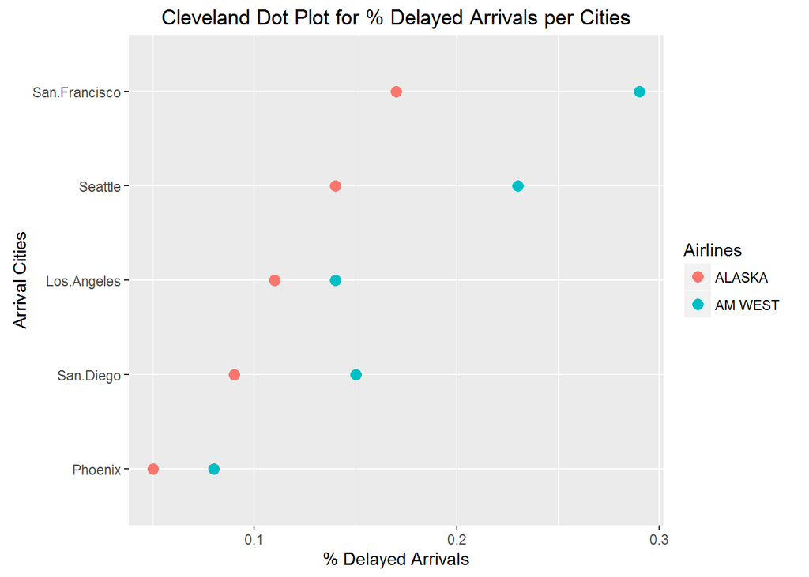

```r
# Display cleveland plot
ggplot(temp_table5, aes(x=delays_ratio, y=reorder(cities, delays_ratio), colour = Airlines)) + geom_point(size=3) + ggtitle("Cleveland Dot Plot for % Delayed Arrivals per Cities") + labs(x="% Delayed Arrivals", y="Arrival Cities")
```

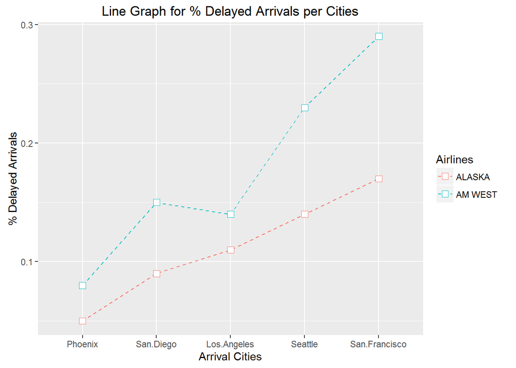

```r
# Display line plot
ggplot(temp_table5, aes(x=reorder(cities, delays_ratio), y=delays_ratio, colour = Airlines, group = Airlines)) + geom_line(linetype = "dashed") + geom_point(shape = 22, size = 3, fill = "white") + ggtitle("Line Graph for % Delayed Arrivals per Cities") + labs(x="Arrival Cities", y="% Delayed Arrivals")
```